# 04_E_Classical_Decomposition_fromScratch

Author

Juan Garbayo - TS Analysis

# References

NOTE: this material is not original, but rather an extension of the following reference, which is publicly available.

1. Hyndman, R.J., & Athanasopoulos, G., 2021. *Forecasting: principles and practice*. 3rd edition. [Link](https://otexts.com/fpp3/)

# Packages

```r
library(fpp3)
```

# Classical decomposition:

It is the starting point for most other methods of time series decomposition. In addition, it is simple enough that it can be easily implemented from scratch, which is something we are going to do in class.

Essentially are 2 variants of classical decomposition:

- Classical decomposition of **aditive schemes**
- Classical decomposition of **multiplicative schemes**

The algorithm depends on **whether the length seasonal period is even or uneven.** Examples:

- If we have daily data we may consider, for example, a period of one week. That seasonal period would be of length 7 (7 days).
  - NOTE: For daily data we could also consider other seasonal periods: one month, one quarter… even one year.
- If we have monthly data, we could consider a yearly seasonal period. That seasonal period would be of length 12 (12 months).
- If we have quarterly data, we could consider a yearly seasonal period. That seasonal period would be of length 4 (4 quarters).
- …

Because the algorithm **approximates the trend with a centered moving average**, the even or uneven nature of the seasonal period is important. See the separate notebook on moving averages, which has an associated video to understand this:

- **Even seasonal period ($m$ even):** trend approximated by a 2 x $m$ moving average.
- **Uneven seasonal period $m$:** trend approximated by an $m$ moving average.

# Additive schemes - classical decomposition

## Step 1 - Estimate trend

$m$: length of the seasonal period.

- If $m$ is an even number, compute the trend-cycle component $T_t$ using 2 x $m$-MA.
- If $m$ is an odd number compute the trend-cycle component $T_t$ using an $m$-MA.

**Output**: the **trend component $T_t$**

## Step 2 - Detrended series

Calculate the de-trended series: $D_t = y_t - T_t$

**Output**: the **detrended series $D_t$**

## Step 3 - Compute seasonal component

**Main assumption to compute the seasonal component**: the seasonal component remains constant over time. This is one of the main weaknesses of the classical decomposition.

**Step 3.1.** Average the de-trended values for each component of the season.

- Example: with monthly data the seasonal component for march is the average of all the detrended March values in the data
- **Output**: a vector of length $m$, with $m$ being the length of the seasonal compoent.
  - Let us call this vector **$S_{unadj}$** for *unadjusted seasonal component*

**Step 3.2.** Adjust $S_{unadj}$, the output of step 3.1 to ensure that the sum of its **values adds to 0**.

- 3.2.1 Sum all the components of the vector $S_{unadj}$. Lets call this output $a$. This result is the total deviation from 0 we want to correct.
- 3.2.2 Divide the previous result $a$ by the length of the seasonal period $m$. Then subtract that amount $a/m$ from every component of $S_{unadj}$
- **Output**: the seasonal component $S$.

By doing this the seasonal component will not contribute to the mean value of the time series over one period. That is, the average of the seasonal component computed in this manner over one period will be 0.

$$\text{condition imposed: }\sum_{i=1}^{m} S_i= 0$$

As a result, the seasonal component does not contribute to the average of the time series over one period

$$\frac{\sum_{i=1}^my_i}{m} = \frac{\sum_{i=1}^m(T_i + S_i + R_i)}{m} \underset{\underset{\sum_{i=1}^mS_i = 0}{\uparrow}}{=} \frac{\sum_{i=1}^m(T_i + R_i)}{m}$$

## Step 4 - Compute the remainder component

$R_t = D_t - S_t = y_t - T_t - S_t$

## Example: computation using the function `classical_decomposition()`:

```r
# Filter the series and select relevant columns
us_retail_employment <- us_employment %>%
  filter(year(Month) >= 1990, Title == "Retail Trade") %>%
  select(-Series_ID)

# Let us compute the classical decomposition using the function in the feasts library:
classical_dec <- us_retail_employment %>%

  # Fit the classical decomposition model specifying an additive scheme
  model(
    clas_deic = classical_decomposition(Employed, type = "additive")
  ) %>%

  # Extract components from the fitted model
  components()

select(classical_dec, Month, Employed, trend, seasonal, random)
```

```
# A tsibble: 357 x 5 [1M]
      Month Employed  trend seasonal random
      <mth>    <dbl>  <dbl>    <dbl>  <dbl>
 1 1990 Jan   13256.    NA    -75.5   NA
 2 1990 Feb   12966.    NA   -273.    NA
 3 1990 Mar   12938.    NA   -253.    NA
 4 1990 Apr   13012.    NA   -190.    NA
 5 1990 May   13108.    NA    -88.9   NA
 6 1990 Jun   13183.    NA    -10.4   NA
 7 1990 Jul   13170. 13178.   -13.3    5.65
 8 1990 Aug   13160. 13161.    -9.99   8.80
 9 1990 Sep   13113. 13141.   -87.4   59.9
10 1990 Oct   13185. 13117.    34.6   33.8
# ℹ 347 more rows
```

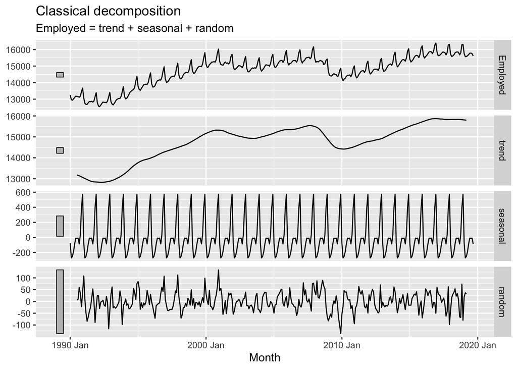

```r
classical_dec %>%
  autoplot()
```

## Example: manual computation implementing the described algorithm.

### Step 1: compute the trend using moving averages

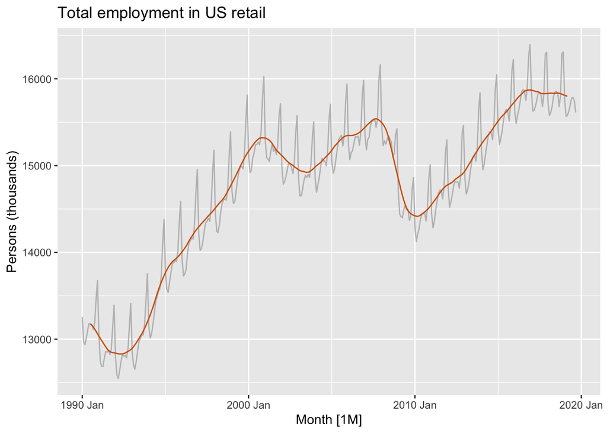

```r
# Compute moving averages to estimate the trend
# Because the seasonal period is 12, we need a 2x12-MA
manual_decomposition <- us_retail_employment %>%
  mutate(

    `12-MA` = slider::slide_dbl(Employed, mean,
                .before = 5, .after = 6, .complete = TRUE),
    `2x12-MA` = slider::slide_dbl(`12-MA`, mean,
                .before = 1, .after = 0, .complete = TRUE)

  )

# Plot the computed trend
manual_decomposition %>%
  autoplot(Employed, colour = "gray") +
  geom_line(aes(y = `2x12-MA`), colour = "#D55E00") +
  labs(y = "Persons (thousands)",
       title = "Total employment in US retail")
```

### Step 2 - detrend the time series

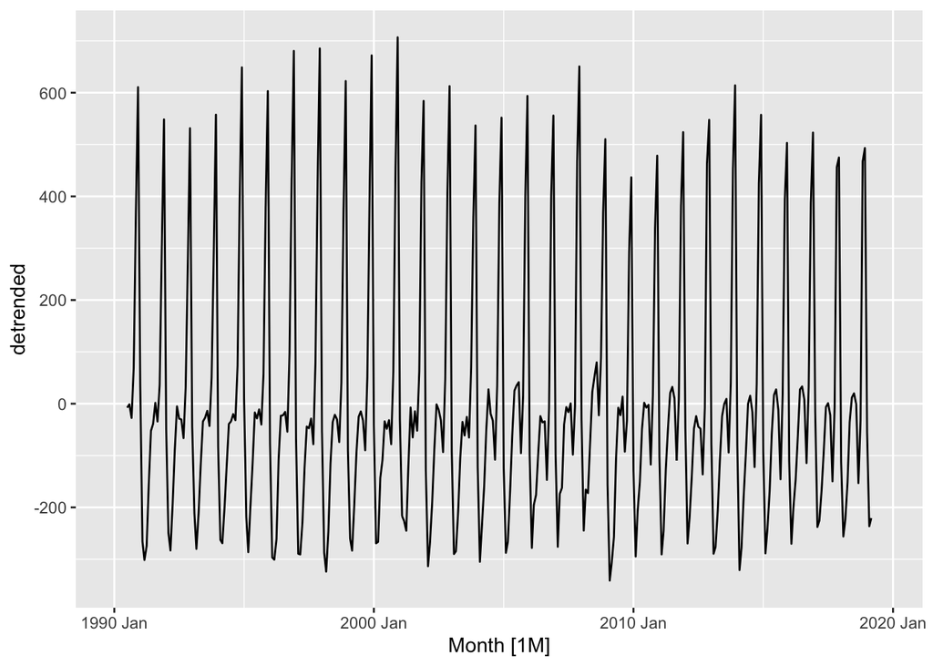

```r
# Compute the detrended component:
manual_decomposition <-
  manual_decomposition %>%
  mutate(
      detrended = Employed - `2x12-MA`,
    )
manual_decomposition %>% autoplot(detrended)
```

This is the resulting detrended component, which contains the seasonal + remainder component: $D_t = y_t - T_t = S_t + R_t$

### Step 3: compute the seasonal component

#### Step 3.1. Compute $S_{unadj}$ averaging the de-trended values for each element of the season:

We will store the result in a separate dataframe called `df_seasonal`. This dataframe will contain 2 columns:

1. An identifier for the number of the month. This identifier will be based solely on the month, disregarding the year. More generally, we need to compute an identifier for each element of the seasonal component.
   - We will use this identifier to group the data and compute the mean value
2. `s_unadj`: we compute it averaging the detrended series grouping based on the previously created identifier. For example, with monthly data, the seasonal component for March is the average of all the detrended March values in the data.

We will start by creating the mentioned identifier for each month (disregarding the year) on our dataframe:

```r
manual_decomposition <-

  manual_decomposition %>%

  # Compute an identifier for each month, regardless
  # of the year. This will define the subsequent groups
  mutate(
    n_month = month(Month)
  )

manual_decomposition
```

```
# A tsibble: 357 x 7 [1M]
      Month Title        Employed `12-MA` `2x12-MA` detrended n_month
      <mth> <chr>           <dbl>   <dbl>     <dbl>     <dbl>   <dbl>
 1 1990 Jan Retail Trade   13256.     NA        NA      NA          1
 2 1990 Feb Retail Trade   12966.     NA        NA      NA          2
 3 1990 Mar Retail Trade   12938.     NA        NA      NA          3
 4 1990 Apr Retail Trade   13012.     NA        NA      NA          4
 5 1990 May Retail Trade   13108.     NA        NA      NA          5
 6 1990 Jun Retail Trade   13183.  13186.       NA      NA          6
 7 1990 Jul Retail Trade   13170.  13170.    13178.     -7.66       7
 8 1990 Aug Retail Trade   13160.  13151.    13161.     -1.20       8
 9 1990 Sep Retail Trade   13113.  13130.    13141.    -27.5        9
10 1990 Oct Retail Trade   13185.  13103.    13117.     68.5       10
# ℹ 347 more rows
```

Now we will use this newly created identifier to compute the averages of the detrended time series for each month regardless of the year. Expressed in more general terms, we are computing the averages of the detrended time series for each element of the seasonal component.

```r
df_seasonal <-

  manual_decomposition %>%

  # turn into a tibble to be able to use group_by
  # without the limitations on a tsibble
  as_tibble() %>%

  # group by the created identifier
  group_by(n_month) %>%

  # compute the average seasonal component for every month
  summarise(
    s_unadj = mean(detrended, na.rm = TRUE)
  ) %>%

  ungroup() %>%

  # Turn back into a tsibble
  as_tsibble(index = n_month)

df_seasonal
```

```
# A tsibble: 12 x 2 [1]
   n_month s_unadj
     <dbl>   <dbl>
 1       1   -75.5
 2       2  -273.
 3       3  -253.
 4       4  -190.
 5       5   -88.9
 6       6   -10.4
 7       7   -13.3
 8       8   -10.0
 9       9   -87.4
10      10    34.6
11      11   394.
12      12   573.
```

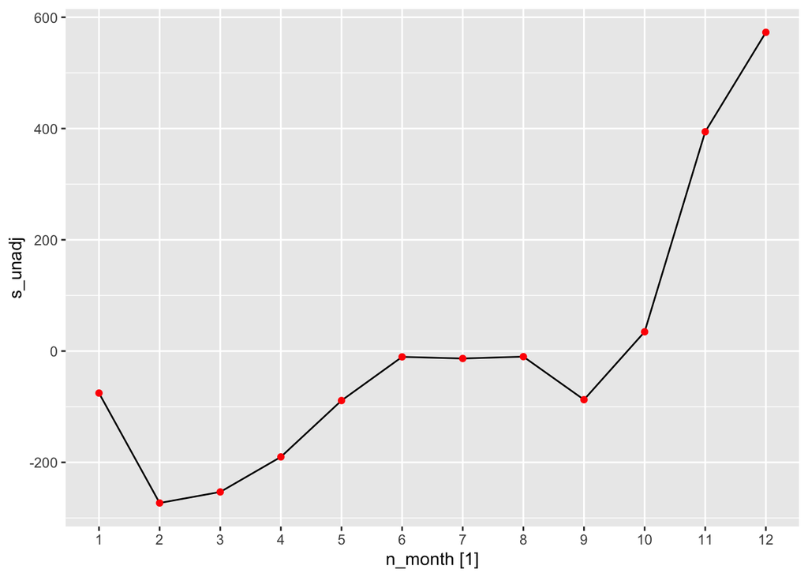

```r
#Check the aspect of the obtained unadjusted seasonal component
df_seasonal %>%

  autoplot(s_unadj) +

  scale_x_continuous(breaks = seq(1, 12),
                     minor_breaks = seq(1, 12)) +

  geom_point(color = "red")
```

This is the resulting unadjusted seasonal component $S_{unadj}$:

- The first point is the unadjusted value of the seasonal component for January.
- The second point is the unadjusted value of the seasonal component for February.
- The third point is the unadjusted value of the seasonal component for March.
- …

#### Step 3.2 Adjust the seasonal component

Let us check if the values of the component add up to 0 as we wanted to impose:

```r
#The sum does not add up to 0
a = sum(df_seasonal$s_unadj)
a
```

```
[1] -0.2273091
```

We can see that the sum is not 0. We will divide the sum by the length of the seasonal component (in this case $m$ = 12) and then distribute this deviation from 0 evenly over the seasonal component.

```r
df_seasonal <-

  df_seasonal %>%

  # Correction so that the sum of the seasoan components is 0
  mutate(
        seasonal_c = s_unadj  - a/12
    ) %>%

  # Drop s_unadj since we do not need it anymore.
  select(n_month, seasonal_c)

sum(df_seasonal$seasonal_c)
```

```
[1] 1.136868e-13
```

As you can see, the seasonal component is now 0. Great. Let us bring the seasonal component back into our original dataset. For this we will use a `left join` operation. Remember that we created previously a column called `n_month` that now will come in handy when doing this join:

```r
# Bring seasonal component into the dataset (I chose to use a "join" statement, very convenient)
manual_decomposition <-
  left_join(manual_decomposition, df_seasonal, by = "n_month")

manual_decomposition
```

```
# A tsibble: 357 x 8 [1M]
      Month Title        Employed `12-MA` `2x12-MA` detrended n_month seasonal_c
      <mth> <chr>           <dbl>   <dbl>     <dbl>     <dbl>   <dbl>      <dbl>
 1 1990 Jan Retail Trade   13256.     NA        NA      NA          1     -75.5
 2 1990 Feb Retail Trade   12966.     NA        NA      NA          2    -273.
 3 1990 Mar Retail Trade   12938.     NA        NA      NA          3    -253.
 4 1990 Apr Retail Trade   13012.     NA        NA      NA          4    -190.
 5 1990 May Retail Trade   13108.     NA        NA      NA          5     -88.9
 6 1990 Jun Retail Trade   13183.  13186.       NA      NA          6     -10.4
 7 1990 Jul Retail Trade   13170.  13170.    13178.     -7.66       7     -13.3
 8 1990 Aug Retail Trade   13160.  13151.    13161.     -1.20       8      -9.99
 9 1990 Sep Retail Trade   13113.  13130.    13141.    -27.5        9     -87.4
10 1990 Oct Retail Trade   13185.  13103.    13117.     68.5       10      34.6
# ℹ 347 more rows
```

### Step 4: compute the remainder component removing the seasonal component from the detrended series

Now that we have the seasonal component, we obtain the remainder component by subtracting it from the de-trended series.

```r
# Compute remainder component:
manual_decomposition <-
  manual_decomposition %>%
  mutate(
        remainder = detrended - seasonal_c
      )

select(manual_decomposition, Month, `2x12-MA`, seasonal_c, remainder)
```

```
# A tsibble: 357 x 4 [1M]
      Month `2x12-MA` seasonal_c remainder
      <mth>     <dbl>      <dbl>     <dbl>
 1 1990 Jan       NA      -75.5      NA
 2 1990 Feb       NA     -273.       NA
 3 1990 Mar       NA     -253.       NA
 4 1990 Apr       NA     -190.       NA
 5 1990 May       NA      -88.9      NA
 6 1990 Jun       NA      -10.4      NA
 7 1990 Jul    13178.     -13.3       5.65
 8 1990 Aug    13161.      -9.99      8.80
 9 1990 Sep    13141.     -87.4      59.9
10 1990 Oct    13117.      34.6      33.8
# ℹ 347 more rows
```

### Test result:

We have all the components. We are now going to compute the maximum absolute errors of our manual computation, comparing it with the result provided by the function `classical_decomposition()`

```r
# Evaluation of absolute errors
max_err_seasonal = max(classical_dec$seasonal - manual_decomposition$seasonal_c, na.rm = TRUE)
max_err_trend = max(classical_dec$trend - manual_decomposition$`2x12-MA`, na.rm = TRUE)
max_err_rand = max(classical_dec$random - manual_decomposition$remainder, na.rm = TRUE)

# Compute the max value of all these vectors
max(c(max_err_seasonal, max_err_trend, max_err_rand))
```

```
[1] 6.025402e-12
```

The result is not 0 but it is sufficiently close to 0 that we can attribute this deviation to numerical errors (particularly given the fact that this error is much smaller than any of the components we want to compute).

### Extra: generate a plot of the components we just created

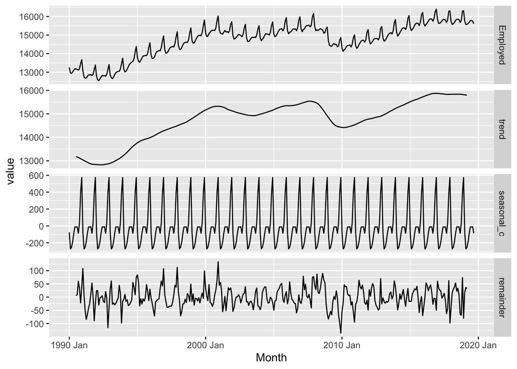

```r
# As an additional ggplot visualization exercise, below the code to visualize
# the decomposition we have computed manually

# Define levels for the factor variable to ensure proper ordering
# in the facet grid figure.
factor_levels = c("Employed", "trend", "seasonal_c", "remainder")

manual_decomposition_long <-

  manual_decomposition %>%

    # Rename so that the labels are consistent
    rename(trend = `2x12-MA`) %>%

    # Select the columns of interest
    select(Month, Employed, trend, seasonal_c, remainder) %>%

    # Generate long format based on a single variable so that we can
    # facet_grid following this variable
    pivot_longer(cols = Employed:remainder, names_to = "component") %>%

    # Convert to factor to ensure proper ordering in the figure
    mutate(
      component = factor(component, levels=factor_levels)
    )

# Now generate the graph
manual_decomposition_long %>%

  ggplot(aes(x = Month, y = value)) +

  geom_line() +

  # scales = "free_y" so that each component has an adapted y-axis range
  facet_grid(component ~ ., scales = "free_y")
```

We can see that it looks just like the decomposition returned by the fable library.

# Multiplicative scheme - classical decomposition

In this case substractions are simply replaced by divisions.

## Step 1 - Estimate trend

$m$: length of the seasonal period.

- If $m$ is an even number, compute the trend-cycle component $T_t$ using 2 x $m$-MA.
- If $m$ is an odd number compute the trend-cycle component $T_t$ using an $m$-MA.

## Step 2 - Detrended series

Calculate the de-trended series: $y_t / \hat{T_t}$

## Step 3 - Compute seasonal component

**Main assumption to compute the seasonal component**: the seasonal component remains constant over time. This is one of the main weaknesses of the classical decomposition.

**Step 3.1.** Average the de-trended values for each component of the season.

- Example: with monthly data the seasonal component for march is the average of all the detrended March values in the data
- **Output**: a vector of length $m$, with $m$ being the length of the seasonal compoent.
  - Let us call this vector **$S_{unadj}$** for *unadjusted seasonal component*

**Step 3.2.** Adjust $S_{unadj}$, the output of step 3.1 to ensure that the sum of its elements **equals $m$**.

- 3.2.1 Sum all the components of the vector $S_{unadj}$. Lets call this output $a$.

$$\sum_{i=1}^mS_{unadj\text{ i}} = a$$

- 3.2.2 Compute the necessary correction $x$ to be performed on $S_{unadj}$ to have a sum equal to $m$:

$$\begin{align*}
\text{Condition we want to attain}: && \sum_{i=1}^m{S_i} = m \\
\text{Therefore: } && \sum_{i=1}^m{S_i} = \sum_{i=1}^mS_{unadj\text{ i}} + x = a + x = m \\
\text{Resulting correction x: } && x = m - a = m - \sum_{i=1}^mS_{unadj\text{ i}}
\end{align*}$$

Now we divide $x$ by $m$ and add this quantity to each element of $S_{unadj}$

- **Output**: the seasonal component $S$. Check at this point that the following condition is fulfilled:

$$\text{condition imposed: }\sum_{i=1}^m{S_i} = m$$

By doing this, the sum of the time series over a seasonal period becomes a weighted average of $T_iR_i$:

$$\frac{\sum_{i=1}^m(T_i S_i R_i)}{m} = \underbrace{\sum_{i=1}^m\frac{S_i}{m}(T_i R_i) }_{\text{weighted avg.} \\ \text{of } R_iT_i \text{ since } \sum_{i=1}^mS_i/m = 1}$$

## Step 4 - Compute the remainder component

$\hat{R} = y_t / T_tS_t = D_t / S_t$

# Exercise 1

Consider the last five years of the Gas data from `aus_production`

```r
gas <- tail(aus_production, 5*4) %>% select(Gas)
gas
```

```
# A tsibble: 20 x 2 [1Q]
     Gas Quarter
   <dbl>   <qtr>
 1   221 2005 Q3
 2   180 2005 Q4
 3   171 2006 Q1
 4   224 2006 Q2
 5   233 2006 Q3
 6   192 2006 Q4
 7   187 2007 Q1
 8   234 2007 Q2
 9   245 2007 Q3
10   205 2007 Q4
11   194 2008 Q1
12   229 2008 Q2
13   249 2008 Q3
14   203 2008 Q4
15   196 2009 Q1
16   238 2009 Q2
17   252 2009 Q3
18   210 2009 Q4
19   205 2010 Q1
20   236 2010 Q2
```

1. Use `classical_decomposition` with `type=multiplicative` to calculate the trend-cycle and seasonal indices

```r
# Let us compute the classical decomposition using the function in the feasts library:
classical_dec <- gas %>%
  model(
    classical_decomposition(Gas ~ season(4), type = "multiplicative")
  ) %>%
  components()

classical_dec
```

```
# A dable: 20 x 7 [1Q]
# Key:     .model [1]
# :        Gas = trend * seasonal * random
   .model                      Quarter   Gas trend seasonal random season_adjust
   <chr>                         <qtr> <dbl> <dbl>    <dbl>  <dbl>         <dbl>
 1 "classical_decomposition(G… 2005 Q3   221   NA     1.13  NA              196.
 2 "classical_decomposition(G… 2005 Q4   180   NA     0.925 NA              195.
 3 "classical_decomposition(G… 2006 Q1   171  200.    0.875  0.974          195.
 4 "classical_decomposition(G… 2006 Q2   224  204.    1.07   1.02           209.
 5 "classical_decomposition(G… 2006 Q3   233  207     1.13   1.00           207.
 6 "classical_decomposition(G… 2006 Q4   192  210.    0.925  0.987          208.
 7 "classical_decomposition(G… 2007 Q1   187  213     0.875  1.00           214.
 8 "classical_decomposition(G… 2007 Q2   234  216.    1.07   1.01           218.
 9 "classical_decomposition(G… 2007 Q3   245  219.    1.13   0.996          218.
10 "classical_decomposition(G… 2007 Q4   205  219.    0.925  1.01           222.
11 "classical_decomposition(G… 2008 Q1   194  219.    0.875  1.01           222.
12 "classical_decomposition(G… 2008 Q2   229  219     1.07   0.974          213.
13 "classical_decomposition(G… 2008 Q3   249  219     1.13   1.01           221.
14 "classical_decomposition(G… 2008 Q4   203  220.    0.925  0.996          219.
15 "classical_decomposition(G… 2009 Q1   196  222.    0.875  1.01           224.
16 "classical_decomposition(G… 2009 Q2   238  223.    1.07   0.993          222.
17 "classical_decomposition(G… 2009 Q3   252  225.    1.13   0.994          224.
18 "classical_decomposition(G… 2009 Q4   210  226     0.925  1.00           227.
19 "classical_decomposition(G… 2010 Q1   205   NA     0.875 NA              234.
20 "classical_decomposition(G… 2010 Q2   236   NA     1.07  NA              220.
```

2. Compute and plot the seasonally adjusted data.

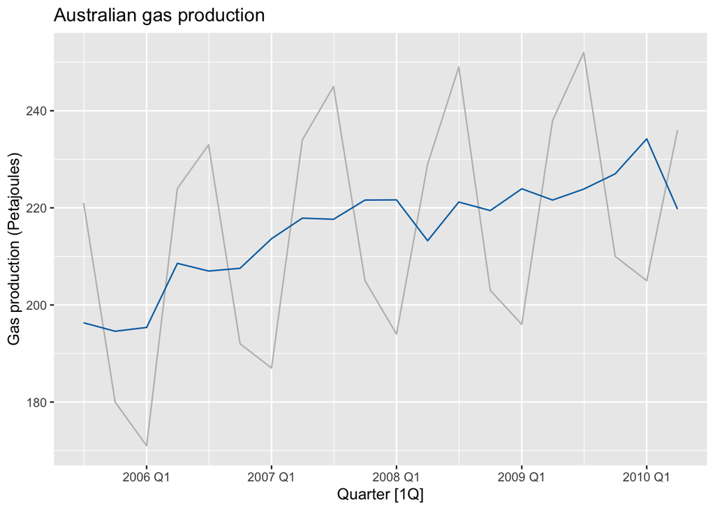

```r
classical_dec %>%

  as_tsibble() %>%

  autoplot(Gas, colour = "gray") +
  geom_line(aes(y=season_adjust), colour = "#0072B2") +
  labs(y = "Gas production (Petajoules)",
       title = "Australian gas production")
```

3. Compute manually the classical decomposition of the series (as we did in class, but keep in mind that this scheme is multiplicative and that now the seasonal period is 4 instead of 12).

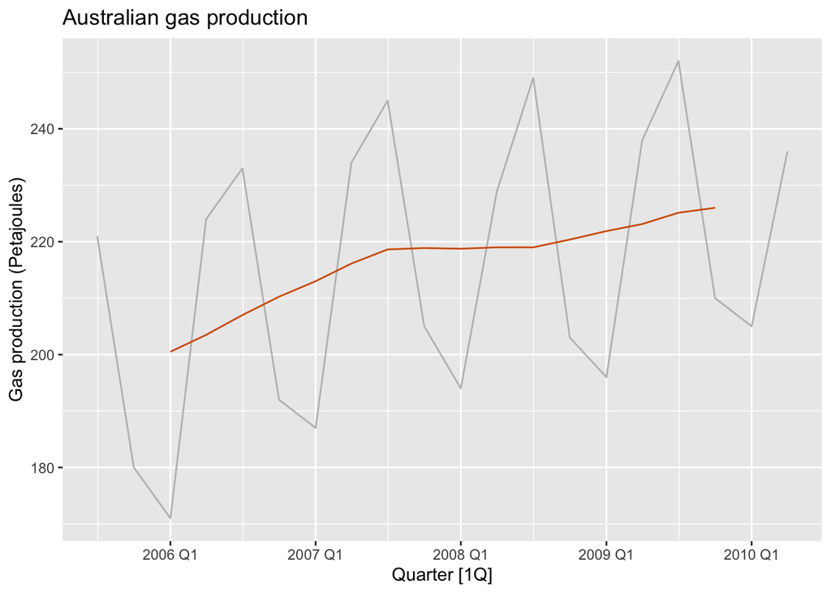

```r
### 1. Compute the trend with a 2x4 MA

# Compute moving averages
# Because the seasonal period is 12, we need a 2x12-MA
manual_decomposition <- gas %>%
  mutate(
    `4-MA` = slider::slide_dbl(Gas, mean,
                     .before = 1, .after = 2, .complete = TRUE),
    `2x4-MA` = slider::slide_dbl(`4-MA`, mean,
                      .before = 1, .after = 0, .complete = TRUE)
  )

# Plot the computed trend
manual_decomposition %>%
  autoplot(Gas, colour = "gray") +
  geom_line(aes(y = `2x4-MA`), colour = "#D55E00") +
  labs(y = "Gas production (Petajoules)",
       title = "Australian gas production")
```

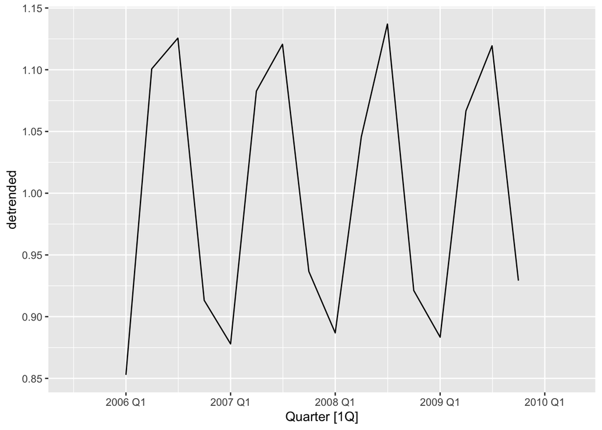

```r
### 2. Compute the de-trended component:

# Compute the detrended component:
manual_decomposition <- manual_decomposition %>%
  mutate(detrended = Gas / `2x4-MA`,
         n_quarter = quarter(Quarter)) # Add an identifier for the month (used later for a join statement)

manual_decomposition %>% autoplot(detrended)
```

```r
### 3. Compute the seasonal component grouping and averaging the detrended component

res <- manual_decomposition %>%
  index_by(n_quarter) %>%

  #Compute seasonal component
  summarise(
    seasonal_c = mean(detrended, na.rm = TRUE)
  )

res
```

```
# A tsibble: 4 x 2 [1]
  n_quarter seasonal_c
      <int>      <dbl>
1         1      0.875
2         2      1.07
3         3      1.13
4         4      0.925
```

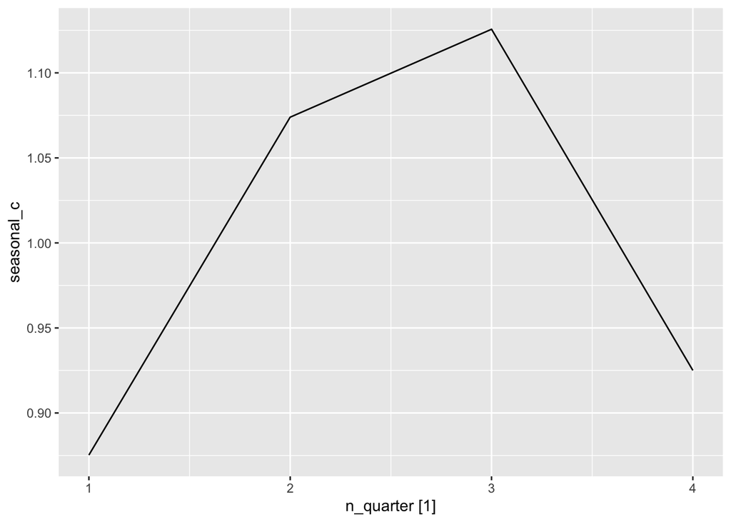

```r
#Check the aspect of the obtained seasonal component
res %>%
  autoplot(seasonal_c)
```

```r
### 4. Correct the seasonal components so that they add to m = 4

m = 4
sum_dev = m - sum(res$seasonal_c)

res <- res %>%
  # Correction so that the sum of the seasoan components is 0
  mutate(seasonal_c = seasonal_c  + sum(sum_dev)/m)

sum(res$seasonal_c)
```

```
[1] 4
```

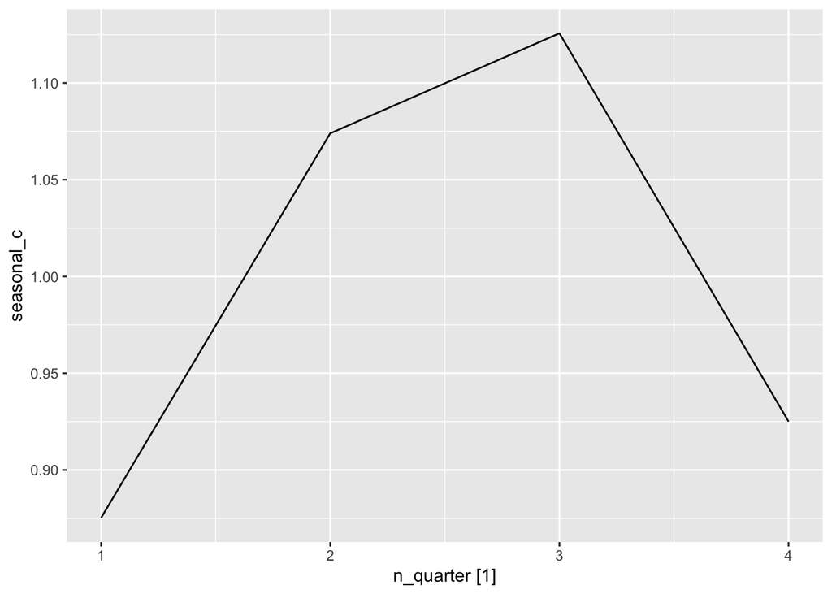

```r
#Check the aspect of the obtained seasonal component
res %>%
  autoplot(seasonal_c)
```

```r
# Bring seasonal component into the dataset
# (I chose to use a "join" statement, very convenient)
manual_decomposition <- left_join(manual_decomposition, res, by = "n_quarter")
manual_decomposition
```

```
# A tsibble: 20 x 7 [1Q]
     Gas Quarter `4-MA` `2x4-MA` detrended n_quarter seasonal_c
   <dbl>   <qtr>  <dbl>    <dbl>     <dbl>     <int>      <dbl>
 1   221 2005 Q3    NA       NA     NA             3      1.13
 2   180 2005 Q4   199       NA     NA             4      0.925
 3   171 2006 Q1   202      200.     0.853         1      0.875
 4   224 2006 Q2   205      204.     1.10          2      1.07
 5   233 2006 Q3   209      207      1.13          3      1.13
 6   192 2006 Q4   212.     210.     0.913         4      0.925
 7   187 2007 Q1   214.     213      0.878         1      0.875
 8   234 2007 Q2   218.     216.     1.08          2      1.07
 9   245 2007 Q3   220.     219.     1.12          3      1.13
10   205 2007 Q4   218.     219.     0.937         4      0.925
11   194 2008 Q1   219.     219.     0.887         1      0.875
12   229 2008 Q2   219.     219      1.05          2      1.07
13   249 2008 Q3   219.     219      1.14          3      1.13
14   203 2008 Q4   222.     220.     0.921         4      0.925
15   196 2009 Q1   222.     222.     0.883         1      0.875
16   238 2009 Q2   224      223.     1.07          2      1.07
17   252 2009 Q3   226.     225.     1.12          3      1.13
18   210 2009 Q4   226.     226      0.929         4      0.925
19   205 2010 Q1    NA       NA     NA             1      0.875
20   236 2010 Q2    NA       NA     NA             2      1.07
```

```r
# Compute remainder component:
manual_decomposition <- manual_decomposition %>%
  mutate(remainder = detrended / seasonal_c)

select(manual_decomposition, Quarter, Gas, `2x4-MA`, seasonal_c, remainder)
```

```
# A tsibble: 20 x 5 [1Q]
   Quarter   Gas `2x4-MA` seasonal_c remainder
     <qtr> <dbl>    <dbl>      <dbl>     <dbl>
 1 2005 Q3   221      NA       1.13     NA
 2 2005 Q4   180      NA       0.925    NA
 3 2006 Q1   171     200.      0.875     0.974
 4 2006 Q2   224     204.      1.07      1.02
 5 2006 Q3   233     207       1.13      1.00
 6 2006 Q4   192     210.      0.925     0.987
 7 2007 Q1   187     213       0.875     1.00
 8 2007 Q2   234     216.      1.07      1.01
 9 2007 Q3   245     219.      1.13      0.996
10 2007 Q4   205     219.      0.925     1.01
11 2008 Q1   194     219.      0.875     1.01
12 2008 Q2   229     219       1.07      0.974
13 2008 Q3   249     219       1.13      1.01
14 2008 Q4   203     220.      0.925     0.996
15 2009 Q1   196     222.      0.875     1.01
16 2009 Q2   238     223.      1.07      0.993
17 2009 Q3   252     225.      1.13      0.994
18 2009 Q4   210     226       0.925     1.00
19 2010 Q1   205      NA       0.875    NA
20 2010 Q2   236      NA       1.07     NA
```

```r
# Evaluation of absolute errors
max_err_seasonal = max(classical_dec$seasonal - manual_decomposition$seasonal_c, na.rm = TRUE)
max_err_trend = max(classical_dec$trend - manual_decomposition$`2x4-MA`, na.rm = TRUE)
max_err_rand = max(classical_dec$random - manual_decomposition$remainder, na.rm = TRUE)

max(c(max_err_seasonal, max_err_trend, max_err_rand))
```

```
[1] 3.720274e-06
```

```r
The errors are small enough for us to consider that we have correctly
implemented the algorithm in the function `classical_decomposition()`.

It would be interesting to explore the specific reasons for this deviation,
but that is something we will not do.
```

4. Change one observations to be an outlier (e.g., add 300 to one observation), and recompute the seasonally adjusted data. What is the effect of the outlier?

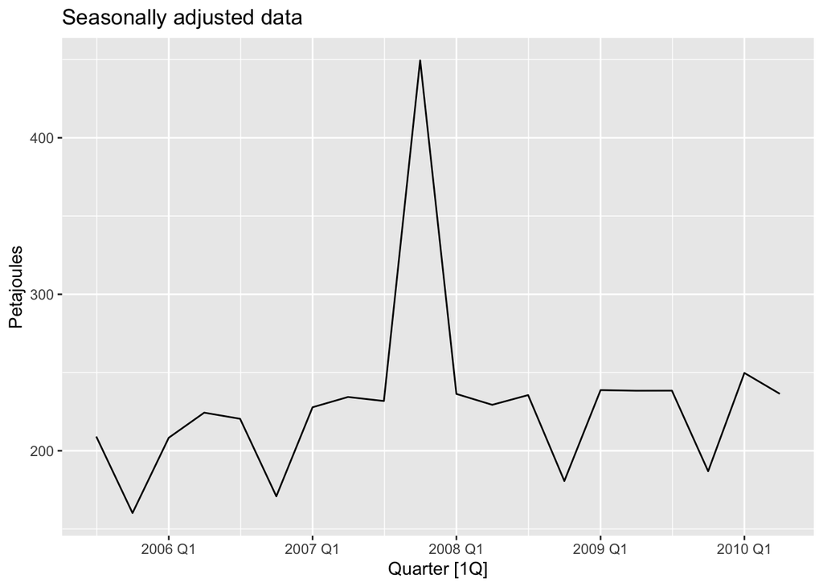

```r
gas %>%
  mutate(Gas = if_else(Quarter == yearquarter("2007Q4"), Gas + 300, Gas)) %>%
  model(decomp = classical_decomposition(Gas, type = "multiplicative")) %>%
  components() %>%
  as_tsibble() %>%
  autoplot(season_adjust) +
  labs(title = "Seasonally adjusted data", y = "Petajoules")
```

```r
* The outlier is more or less in the middle of the series.
* The trend is approximated using a 2x4-MA. Since the outlier is in the middle
of the series, this information is in the region where the moving average can
be computed and the information of the outlier is captured by the trend component.
* The detrended component also inherits the information of the outlier,
since it is computed as $y_t/T_t$.
* The seasonal component is computed averaging this detrended component and
therefore is also affected by the outlier. It will not accurately approximate
the seasonal component.
```

```r
As a result the seasonally adjusted data still has seasonality, because we have
not adequately captured the seasonal component.
```

5. Does it make any difference if the outlier is near the end rather than in the middle of the series?

```r
gas %>%
  mutate(Gas = if_else(Quarter == yearquarter("2010Q2"), Gas + 300, Gas)) %>%
  model(decomp = classical_decomposition(Gas, type = "multiplicative")) %>%
  components() %>%
  as_tsibble() %>%
  autoplot(season_adjust) +
  labs(title = "Seasonally adjusted data", y = "Petajoules")
```

[output not shown]

```r
* The outlier is located at the last point of the series.
* The trend is approximated using a 2x4-MA. Since the outlier is at the very
end of the series, this information is in the region where the 2x4 moving
average cannot be computed and the information of the outlier is not captured
by the trend component.
* The detrended component is defined in exactly the same region as the trend
approximation, since it is computed as $y_t/T_t$. Therefore the detrended
component does not capture the information about the outlier.
* The seasonal component is computed averaging this detrended component.
Therefore it does not inherit information from the outlier. The seasonal
component is not affected by the presence of this outlier.
```